# Risk Factor Analysis

## Outcome Variable

**Outcome Variable:** haz

## Predictor Variables

**Intervention Variable:** perdiar24

**Adjustment Set:**

- arm
- sex
- meducyrs
- feducyrs
- hhwealth_quart
- hfoodsec
- vagbrth
- hdlvry
- W_birthwt
- W_birthlen
- single
- W_nrooms
- month
- brthmon
- impfloor
- impsan
- safeh20
- delta_meducyrs
- delta_feducyrs
- delta_hhwealth_quart
- delta_hfoodsec
- delta_vagbrth
- delta_hdlvry
- delta_W_birthwt
- delta_W_birthlen
- delta_single
- delta_W_nrooms
- delta_month
- delta_brthmon
- delta_impfloor
- delta_impsan
- delta_safeh20

## Stratifying Variables

The analysis was stratified on these variable(s):

- agecat
- studyid
- country

## Data Summary

| agecat | studyid | country | perdiar24 | n_cell | n |
| --- | --- | --- | --- | --- | --- |
| Birth | CMIN | BANGLADESH | 0% | 12 | 26 |
| Birth | CMIN | BANGLADESH | (0%, 5%] | 4 | 26 |
| Birth | CMIN | BANGLADESH | >5% | 10 | 26 |
| Birth | CONTENT | PERU | 0% | 0 | 2 |
| Birth | CONTENT | PERU | (0%, 5%] | 1 | 2 |
| Birth | CONTENT | PERU | >5% | 1 | 2 |
| Birth | EE | PAKISTAN | 0% | 161 | 240 |
| Birth | EE | PAKISTAN | (0%, 5%] | 79 | 240 |
| Birth | EE | PAKISTAN | >5% | 0 | 240 |
| Birth | JiVitA-4 | BANGLADESH | 0% | 76 | 2823 |
| Birth | JiVitA-4 | BANGLADESH | (0%, 5%] | 2449 | 2823 |
| Birth | JiVitA-4 | BANGLADESH | >5% | 298 | 2823 |
| Birth | MAL-ED | BANGLADESH | 0% | 18 | 231 |
| Birth | MAL-ED | BANGLADESH | (0%, 5%] | 131 | 231 |
| Birth | MAL-ED | BANGLADESH | >5% | 82 | 231 |
| Birth | MAL-ED | BRAZIL | 0% | 34 | 65 |
| Birth | MAL-ED | BRAZIL | (0%, 5%] | 29 | 65 |
| Birth | MAL-ED | BRAZIL | >5% | 2 | 65 |
| Birth | MAL-ED | INDIA | 0% | 5 | 47 |
| Birth | MAL-ED | INDIA | (0%, 5%] | 33 | 47 |
| Birth | MAL-ED | INDIA | >5% | 9 | 47 |
| Birth | MAL-ED | NEPAL | 0% | 2 | 27 |
| Birth | MAL-ED | NEPAL | (0%, 5%] | 19 | 27 |
| Birth | MAL-ED | NEPAL | >5% | 6 | 27 |
| Birth | MAL-ED | PERU | 0% | 21 | 233 |
| Birth | MAL-ED | PERU | (0%, 5%] | 89 | 233 |
| Birth | MAL-ED | PERU | >5% | 123 | 233 |
| Birth | MAL-ED | SOUTH AFRICA | 0% | 42 | 113 |
| Birth | MAL-ED | SOUTH AFRICA | (0%, 5%] | 70 | 113 |
| Birth | MAL-ED | SOUTH AFRICA | >5% | 1 | 113 |

[output cut: 102 more lines]

The following strata were considered:

- agecat: 24 months, studyid: CMIN, country: BANGLADESH
- agecat: 24 months, studyid: CONTENT, country: PERU
- agecat: 24 months, studyid: EE, country: PAKISTAN
- agecat: 24 months, studyid: JiVitA-4, country: BANGLADESH
- agecat: 24 months, studyid: MAL-ED, country: BANGLADESH
- agecat: 24 months, studyid: MAL-ED, country: BRAZIL
- agecat: 24 months, studyid: MAL-ED, country: INDIA
- agecat: 24 months, studyid: MAL-ED, country: NEPAL
- agecat: 24 months, studyid: MAL-ED, country: PERU
- agecat: 24 months, studyid: MAL-ED, country: SOUTH AFRICA
- agecat: 24 months, studyid: MAL-ED, country: TANZANIA, UNITED REPUBLIC OF
- agecat: 24 months, studyid: NIH-Birth, country: BANGLADESH
- agecat: 24 months, studyid: NIH-Crypto, country: BANGLADESH
- agecat: 24 months, studyid: PROVIDE, country: BANGLADESH
- agecat: 6 months, studyid: CMIN, country: BANGLADESH
- agecat: 6 months, studyid: CONTENT, country: PERU
- agecat: 6 months, studyid: EE, country: PAKISTAN
- agecat: 6 months, studyid: Guatemala BSC, country: GUATEMALA
- agecat: 6 months, studyid: JiVitA-4, country: BANGLADESH
- agecat: 6 months, studyid: MAL-ED, country: BANGLADESH
- agecat: 6 months, studyid: MAL-ED, country: BRAZIL
- agecat: 6 months, studyid: MAL-ED, country: INDIA
- agecat: 6 months, studyid: MAL-ED, country: NEPAL
- agecat: 6 months, studyid: MAL-ED, country: PERU
- agecat: 6 months, studyid: MAL-ED, country: SOUTH AFRICA
- agecat: 6 months, studyid: MAL-ED, country: TANZANIA, UNITED REPUBLIC OF
- agecat: 6 months, studyid: NIH-Birth, country: BANGLADESH
- agecat: 6 months, studyid: NIH-Crypto, country: BANGLADESH
- agecat: 6 months, studyid: PROVIDE, country: BANGLADESH
- agecat: 6 months, studyid: SAS-FoodSuppl, country: INDIA
- agecat: Birth, studyid: CMIN, country: BANGLADESH
- agecat: Birth, studyid: CONTENT, country: PERU
- agecat: Birth, studyid: EE, country: PAKISTAN
- agecat: Birth, studyid: JiVitA-4, country: BANGLADESH
- agecat: Birth, studyid: MAL-ED, country: BANGLADESH
- agecat: Birth, studyid: MAL-ED, country: BRAZIL
- agecat: Birth, studyid: MAL-ED, country: INDIA
- agecat: Birth, studyid: MAL-ED, country: NEPAL
- agecat: Birth, studyid: MAL-ED, country: PERU
- agecat: Birth, studyid: MAL-ED, country: SOUTH AFRICA
- agecat: Birth, studyid: MAL-ED, country: TANZANIA, UNITED REPUBLIC OF
- agecat: Birth, studyid: NIH-Birth, country: BANGLADESH
- agecat: Birth, studyid: NIH-Crypto, country: BANGLADESH
- agecat: Birth, studyid: PROVIDE, country: BANGLADESH

### Dropped Strata

Some strata were dropped due to rare outcomes:

- agecat: Birth, studyid: CMIN, country: BANGLADESH
- agecat: Birth, studyid: CONTENT, country: PERU
- agecat: Birth, studyid: EE, country: PAKISTAN
- agecat: Birth, studyid: MAL-ED, country: BRAZIL
- agecat: Birth, studyid: MAL-ED, country: NEPAL
- agecat: Birth, studyid: MAL-ED, country: SOUTH AFRICA
- agecat: 6 months, studyid: CMIN, country: BANGLADESH
- agecat: 6 months, studyid: EE, country: PAKISTAN
- agecat: 6 months, studyid: MAL-ED, country: BRAZIL
- agecat: 6 months, studyid: MAL-ED, country: INDIA
- agecat: 6 months, studyid: MAL-ED, country: SOUTH AFRICA
- agecat: 24 months, studyid: CMIN, country: BANGLADESH
- agecat: 24 months, studyid: CONTENT, country: PERU
- agecat: 24 months, studyid: EE, country: PAKISTAN
- agecat: 24 months, studyid: MAL-ED, country: BRAZIL
- agecat: 24 months, studyid: MAL-ED, country: INDIA
- agecat: 24 months, studyid: MAL-ED, country: PERU
- agecat: 24 months, studyid: MAL-ED, country: SOUTH AFRICA

## Methods Detail

We’re interested in the causal parameters $E[Y_a]$ for all values of $a \in \mathcal{A}$. These parameters represent the mean outcome if, possibly contrary to fact, we intervened to set all units to have $A=a$. Under the randomization and positivity assumptions, these are identified by the statistical parameters $\psi_a=E_W[E_{Y|A,W}(Y|A=a,W)]$. In addition, we’re interested in the mean of $Y$, $E[Y]$ under no intervention (the observed mean). We will estimate these parameters by using SuperLearner to fit the relevant likelihood factors – $E_{Y|A,W}(Y|A=a,W)$ and $p(A=a|W)$, and then updating our likelihood fit using a joint TMLE.

For unadjusted analyses ($W=\{\}$), initial likelihoods were estimated using Lrnr_glm to estimate the simple $E(Y|A)$ and Lrnr_mean to estimate $p(A)$. For adjusted analyses, a small library containing Lrnr_glmnet, Lrnr_xgboost, and Lrnr_mean was used.

Having estimated these parameters, we will then use the delta method to estimate relative risks and attributable risks relative to a prespecified baseline level of $A$.

# Results Detail

## Results Plots

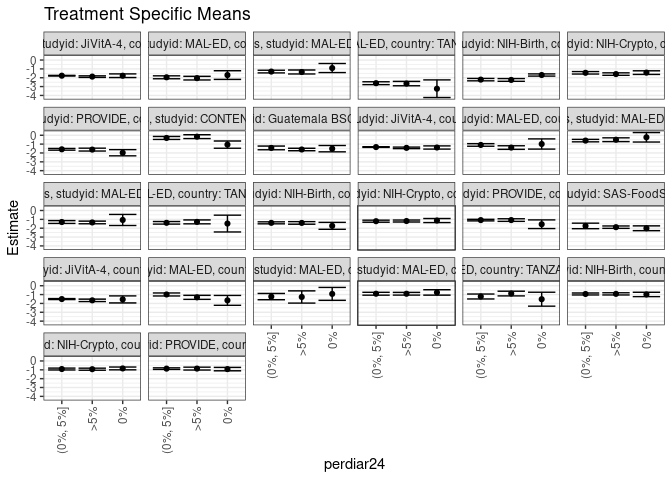

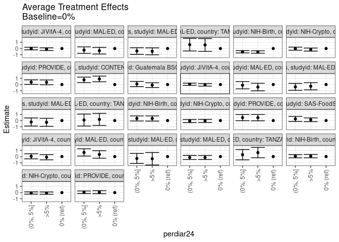

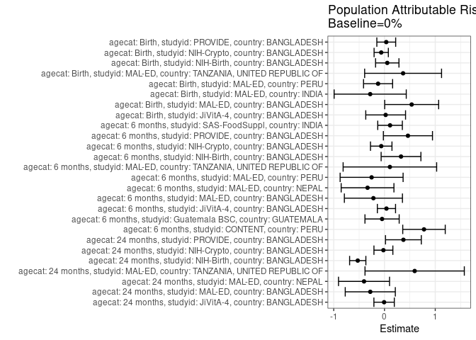

## Results Table

### Parameter: TSM

| agecat | studyid | country | intervention_level | baseline_level | estimate | ci_lower | ci_upper |
| --- | --- | --- | --- | --- | --- | --- | --- |
| Birth | JiVitA-4 | BANGLADESH | 0% | NA | -1.5462178 | -1.9443114 | -1.1481243 |
| Birth | JiVitA-4 | BANGLADESH | (0%, 5%] | NA | -1.5059610 | -1.5588090 | -1.4531131 |
| Birth | JiVitA-4 | BANGLADESH | >5% | NA | -1.6512155 | -1.7876518 | -1.5147792 |
| Birth | MAL-ED | BANGLADESH | 0% | NA | -1.6536273 | -2.2110534 | -1.0962011 |
| Birth | MAL-ED | BANGLADESH | (0%, 5%] | NA | -0.9858878 | -1.1561282 | -0.8156475 |
| Birth | MAL-ED | BANGLADESH | >5% | NA | -1.3127052 | -1.5411820 | -1.0842285 |
| Birth | MAL-ED | INDIA | 0% | NA | -0.9220000 | -1.6509223 | -0.1930777 |
| Birth | MAL-ED | INDIA | (0%, 5%] | NA | -1.2281818 | -1.5833498 | -0.8730139 |
| Birth | MAL-ED | INDIA | >5% | NA | -1.2700000 | -1.9601079 | -0.5798921 |
| Birth | MAL-ED | PERU | 0% | NA | -0.7563864 | -1.0616283 | -0.4511446 |
| Birth | MAL-ED | PERU | (0%, 5%] | NA | -0.9031836 | -1.0653117 | -0.7410555 |
| Birth | MAL-ED | PERU | >5% | NA | -0.9054884 | -1.0571349 | -0.7538420 |
| Birth | MAL-ED | TANZANIA, UNITED REPUBLIC OF | 0% | NA | -1.5222222 | -2.3091001 | -0.7353443 |
| Birth | MAL-ED | TANZANIA, UNITED REPUBLIC OF | (0%, 5%] | NA | -1.2164706 | -1.4939186 | -0.9390226 |
| Birth | MAL-ED | TANZANIA, UNITED REPUBLIC OF | >5% | NA | -0.8822581 | -1.1471959 | -0.6173203 |
| Birth | NIH-Birth | BANGLADESH | 0% | NA | -0.9860050 | -1.2327104 | -0.7392997 |
| Birth | NIH-Birth | BANGLADESH | (0%, 5%] | NA | -0.9320135 | -1.0420866 | -0.8219404 |
| Birth | NIH-Birth | BANGLADESH | >5% | NA | -0.9178748 | -1.0419366 | -0.7938131 |
| Birth | NIH-Crypto | BANGLADESH | 0% | NA | -0.8449782 | -1.0042478 | -0.6857085 |
| Birth | NIH-Crypto | BANGLADESH | (0%, 5%] | NA | -0.9113756 | -1.0159904 | -0.8067607 |
| Birth | NIH-Crypto | BANGLADESH | >5% | NA | -0.9301107 | -1.0461029 | -0.8141184 |
| Birth | PROVIDE | BANGLADESH | 0% | NA | -0.9197854 | -1.1123465 | -0.7272243 |
| Birth | PROVIDE | BANGLADESH | (0%, 5%] | NA | -0.8663784 | -0.9585339 | -0.7742229 |
| Birth | PROVIDE | BANGLADESH | >5% | NA | -0.8622910 | -1.0256785 | -0.6989036 |
| 6 months | CONTENT | PERU | 0% | NA | -1.0567500 | -1.4658384 | -0.6476616 |
| 6 months | CONTENT | PERU | (0%, 5%] | NA | -0.3029472 | -0.4697708 | -0.1361235 |
| 6 months | CONTENT | PERU | >5% | NA | -0.1570746 | -0.3744579 | 0.0603086 |
| 6 months | Guatemala BSC | GUATEMALA | 0% | NA | -1.5141816 | -1.8717479 | -1.1566152 |
| 6 months | Guatemala BSC | GUATEMALA | (0%, 5%] | NA | -1.4283602 | -1.6368243 | -1.2198960 |
| 6 months | Guatemala BSC | GUATEMALA | >5% | NA | -1.6082015 | -1.7472030 | -1.4691999 |
| 6 months | JiVitA-4 | BANGLADESH | 0% | NA | -1.3833713 | -1.5647553 | -1.2019873 |
| 6 months | JiVitA-4 | BANGLADESH | (0%, 5%] | NA | -1.3337926 | -1.3747723 | -1.2928129 |
| 6 months | JiVitA-4 | BANGLADESH | >5% | NA | -1.4235962 | -1.5116176 | -1.3355748 |
| 6 months | MAL-ED | BANGLADESH | 0% | NA | -0.9866667 | -1.5612360 | -0.4120973 |
| 6 months | MAL-ED | BANGLADESH | (0%, 5%] | NA | -1.0936385 | -1.2371707 | -0.9501063 |
| 6 months | MAL-ED | BANGLADESH | >5% | NA | -1.3891039 | -1.5904471 | -1.1877608 |
| 6 months | MAL-ED | NEPAL | 0% | NA | -0.2278907 | -0.7639065 | 0.3081252 |
| 6 months | MAL-ED | NEPAL | (0%, 5%] | NA | -0.6022396 | -0.7392736 | -0.4652056 |
| 6 months | MAL-ED | NEPAL | >5% | NA | -0.5026649 | -0.7153810 | -0.2899487 |
| 6 months | MAL-ED | PERU | 0% | NA | -1.0700000 | -1.6970711 | -0.4429289 |
| 6 months | MAL-ED | PERU | (0%, 5%] | NA | -1.3015443 | -1.4624676 | -1.1406211 |
| 6 months | MAL-ED | PERU | >5% | NA | -1.3503344 | -1.4983707 | -1.2022981 |
| 6 months | MAL-ED | TANZANIA, UNITED REPUBLIC OF | 0% | NA | -1.4750000 | -2.4233687 | -0.5266313 |
| 6 months | MAL-ED | TANZANIA, UNITED REPUBLIC OF | (0%, 5%] | NA | -1.3915631 | -1.5359143 | -1.2472119 |
| 6 months | MAL-ED | TANZANIA, UNITED REPUBLIC OF | >5% | NA | -1.2868579 | -1.5070055 | -1.0667103 |
| 6 months | NIH-Birth | BANGLADESH | 0% | NA | -1.7329754 | -2.1256581 | -1.3402927 |
| 6 months | NIH-Birth | BANGLADESH | (0%, 5%] | NA | -1.3947063 | -1.5085290 | -1.2808835 |
| 6 months | NIH-Birth | BANGLADESH | >5% | NA | -1.4023452 | -1.5478174 | -1.2568731 |
| 6 months | NIH-Crypto | BANGLADESH | 0% | NA | -1.1344562 | -1.3613445 | -0.9075678 |
| 6 months | NIH-Crypto | BANGLADESH | (0%, 5%] | NA | -1.2079238 | -1.3211333 | -1.0947144 |
| 6 months | NIH-Crypto | BANGLADESH | >5% | NA | -1.1885721 | -1.2997142 | -1.0774300 |
| 6 months | PROVIDE | BANGLADESH | 0% | NA | -1.5534245 | -2.0420487 | -1.0648003 |
| 6 months | PROVIDE | BANGLADESH | (0%, 5%] | NA | -1.0839837 | -1.1721549 | -0.9958124 |
| 6 months | PROVIDE | BANGLADESH | >5% | NA | -1.0815788 | -1.2284482 | -0.9347094 |
| 6 months | SAS-FoodSuppl | INDIA | 0% | NA | -2.0081100 | -2.2796293 | -1.7365906 |
| 6 months | SAS-FoodSuppl | INDIA | (0%, 5%] | NA | -1.7429952 | -2.0547160 | -1.4312744 |
| 6 months | SAS-FoodSuppl | INDIA | >5% | NA | -1.8842161 | -2.0206914 | -1.7477409 |
| 24 months | JiVitA-4 | BANGLADESH | 0% | NA | -1.7729517 | -1.9784380 | -1.5674653 |
| 24 months | JiVitA-4 | BANGLADESH | (0%, 5%] | NA | -1.7701030 | -1.8072839 | -1.7329221 |
| 24 months | JiVitA-4 | BANGLADESH | >5% | NA | -1.8723767 | -1.9611045 | -1.7836489 |
| 24 months | MAL-ED | BANGLADESH | 0% | NA | -1.6983333 | -2.1891875 | -1.2074792 |
| 24 months | MAL-ED | BANGLADESH | (0%, 5%] | NA | -1.9507308 | -2.1166572 | -1.7848043 |
| 24 months | MAL-ED | BANGLADESH | >5% | NA | -2.0478289 | -2.2529623 | -1.8426955 |
| 24 months | MAL-ED | NEPAL | 0% | NA | -0.9043827 | -1.4158104 | -0.3929551 |
| 24 months | MAL-ED | NEPAL | (0%, 5%] | NA | -1.3034860 | -1.4537545 | -1.1532175 |
| 24 months | MAL-ED | NEPAL | >5% | NA | -1.3503633 | -1.5756489 | -1.1250778 |
| 24 months | MAL-ED | TANZANIA, UNITED REPUBLIC OF | 0% | NA | -3.2400000 | -4.2371443 | -2.2428557 |
| 24 months | MAL-ED | TANZANIA, UNITED REPUBLIC OF | (0%, 5%] | NA | -2.6175962 | -2.7782509 | -2.4569414 |
| 24 months | MAL-ED | TANZANIA, UNITED REPUBLIC OF | >5% | NA | -2.6608654 | -2.9071887 | -2.4145421 |
| 24 months | NIH-Birth | BANGLADESH | 0% | NA | -1.6920000 | -1.8179481 | -1.5660519 |
| 24 months | NIH-Birth | BANGLADESH | (0%, 5%] | NA | -2.2130914 | -2.3480900 | -2.0780928 |
| 24 months | NIH-Birth | BANGLADESH | >5% | NA | -2.2487126 | -2.4051224 | -2.0923029 |
| 24 months | NIH-Crypto | BANGLADESH | 0% | NA | -1.4197813 | -1.6238528 | -1.2157098 |
| 24 months | NIH-Crypto | BANGLADESH | (0%, 5%] | NA | -1.4421355 | -1.5823925 | -1.3018785 |
| 24 months | NIH-Crypto | BANGLADESH | >5% | NA | -1.5864298 | -1.7245601 | -1.4482995 |
| 24 months | PROVIDE | BANGLADESH | 0% | NA | -1.9750000 | -2.3266294 | -1.6233706 |
| 24 months | PROVIDE | BANGLADESH | (0%, 5%] | NA | -1.5859747 | -1.6839331 | -1.4880162 |
| 24 months | PROVIDE | BANGLADESH | >5% | NA | -1.6204885 | -1.7821075 | -1.4588695 |

### Parameter: E(Y)

| agecat | studyid | country | intervention_level | baseline_level | estimate | ci_lower | ci_upper |
| --- | --- | --- | --- | --- | --- | --- | --- |
| Birth | JiVitA-4 | BANGLADESH | NA | NA | -1.5232908 | -1.5723277 | -1.4742539 |
| Birth | MAL-ED | BANGLADESH | NA | NA | -1.1180952 | -1.2525408 | -0.9836496 |
| Birth | MAL-ED | INDIA | NA | NA | -1.2036170 | -1.4976814 | -0.9095527 |
| Birth | MAL-ED | PERU | NA | NA | -0.8827897 | -1.0001058 | -0.7654736 |
| Birth | MAL-ED | TANZANIA, UNITED REPUBLIC OF | NA | NA | -1.1556000 | -1.3655361 | -0.9456639 |
| Birth | NIH-Birth | BANGLADESH | NA | NA | -0.9314050 | -1.0202164 | -0.8425936 |
| Birth | NIH-Crypto | BANGLADESH | NA | NA | -0.9094945 | -0.9809370 | -0.8380521 |
| Birth | PROVIDE | BANGLADESH | NA | NA | -0.8851020 | -0.9601332 | -0.8100709 |
| 6 months | CONTENT | PERU | NA | NA | -0.2785256 | -0.4098735 | -0.1471776 |
| 6 months | Guatemala BSC | GUATEMALA | NA | NA | -1.5619008 | -1.6727702 | -1.4510313 |
| 6 months | JiVitA-4 | BANGLADESH | NA | NA | -1.3447940 | -1.3820261 | -1.3075620 |
| 6 months | MAL-ED | BANGLADESH | NA | NA | -1.2049931 | -1.3222136 | -1.0877726 |
| 6 months | MAL-ED | NEPAL | NA | NA | -0.5615819 | -0.6741832 | -0.4489807 |
| 6 months | MAL-ED | PERU | NA | NA | -1.3236661 | -1.4316775 | -1.2156546 |
| 6 months | MAL-ED | TANZANIA, UNITED REPUBLIC OF | NA | NA | -1.3687449 | -1.4907629 | -1.2467270 |
| 6 months | NIH-Birth | BANGLADESH | NA | NA | -1.4073821 | -1.4960598 | -1.3187043 |
| 6 months | NIH-Crypto | BANGLADESH | NA | NA | -1.1986783 | -1.2700937 | -1.1272630 |
| 6 months | PROVIDE | BANGLADESH | NA | NA | -1.0916915 | -1.1661176 | -1.0172654 |
| 6 months | SAS-FoodSuppl | INDIA | NA | NA | -1.8986842 | -2.0118892 | -1.7854792 |
| 24 months | JiVitA-4 | BANGLADESH | NA | NA | -1.7807218 | -1.8162478 | -1.7451958 |
| 24 months | MAL-ED | BANGLADESH | NA | NA | -1.9783962 | -2.1050210 | -1.8517715 |
| 24 months | MAL-ED | NEPAL | NA | NA | -1.3075877 | -1.4270718 | -1.1881037 |
| 24 months | MAL-ED | TANZANIA, UNITED REPUBLIC OF | NA | NA | -2.6455607 | -2.7807256 | -2.5103959 |
| 24 months | NIH-Birth | BANGLADESH | NA | NA | -2.2190579 | -2.3217459 | -2.1163699 |
| 24 months | NIH-Crypto | BANGLADESH | NA | NA | -1.4412646 | -1.5249156 | -1.3576135 |
| 24 months | PROVIDE | BANGLADESH | NA | NA | -1.6024221 | -1.6857420 | -1.5191023 |

### Parameter: ATE

| agecat | studyid | country | intervention_level | baseline_level | estimate | ci_lower | ci_upper |
| --- | --- | --- | --- | --- | --- | --- | --- |
| Birth | JiVitA-4 | BANGLADESH | 0% | 0% | 0.0000000 | 0.0000000 | 0.0000000 |
| Birth | JiVitA-4 | BANGLADESH | (0%, 5%] | 0% | 0.0402568 | -0.3624963 | 0.4430099 |
| Birth | JiVitA-4 | BANGLADESH | >5% | 0% | -0.1049977 | -0.5249442 | 0.3149488 |
| Birth | MAL-ED | BANGLADESH | 0% | 0% | 0.0000000 | 0.0000000 | 0.0000000 |
| Birth | MAL-ED | BANGLADESH | (0%, 5%] | 0% | 0.6677395 | 0.0862283 | 1.2492507 |
| Birth | MAL-ED | BANGLADESH | >5% | 0% | 0.3409221 | -0.2615751 | 0.9434192 |
| Birth | MAL-ED | INDIA | 0% | 0% | 0.0000000 | 0.0000000 | 0.0000000 |
| Birth | MAL-ED | INDIA | (0%, 5%] | 0% | -0.3061818 | -1.1170283 | 0.5046647 |
| Birth | MAL-ED | INDIA | >5% | 0% | -0.3480000 | -1.3517812 | 0.6557812 |
| Birth | MAL-ED | PERU | 0% | 0% | 0.0000000 | 0.0000000 | 0.0000000 |
| Birth | MAL-ED | PERU | (0%, 5%] | 0% | -0.1467972 | -0.4788391 | 0.1852448 |
| Birth | MAL-ED | PERU | >5% | 0% | -0.1491020 | -0.4746464 | 0.1764424 |
| Birth | MAL-ED | TANZANIA, UNITED REPUBLIC OF | 0% | 0% | 0.0000000 | 0.0000000 | 0.0000000 |
| Birth | MAL-ED | TANZANIA, UNITED REPUBLIC OF | (0%, 5%] | 0% | 0.3057516 | -0.5286070 | 1.1401102 |
| Birth | MAL-ED | TANZANIA, UNITED REPUBLIC OF | >5% | 0% | 0.6399642 | -0.1903183 | 1.4702466 |
| Birth | NIH-Birth | BANGLADESH | 0% | 0% | 0.0000000 | 0.0000000 | 0.0000000 |
| Birth | NIH-Birth | BANGLADESH | (0%, 5%] | 0% | 0.0539916 | -0.2035003 | 0.3114835 |
| Birth | NIH-Birth | BANGLADESH | >5% | 0% | 0.0681302 | -0.1969982 | 0.3332586 |
| Birth | NIH-Crypto | BANGLADESH | 0% | 0% | 0.0000000 | 0.0000000 | 0.0000000 |
| Birth | NIH-Crypto | BANGLADESH | (0%, 5%] | 0% | -0.0663974 | -0.2501000 | 0.1173051 |
| Birth | NIH-Crypto | BANGLADESH | >5% | 0% | -0.0851325 | -0.2760302 | 0.1057652 |
| Birth | PROVIDE | BANGLADESH | 0% | 0% | 0.0000000 | 0.0000000 | 0.0000000 |
| Birth | PROVIDE | BANGLADESH | (0%, 5%] | 0% | 0.0534070 | -0.1527848 | 0.2595988 |
| Birth | PROVIDE | BANGLADESH | >5% | 0% | 0.0574944 | -0.1868821 | 0.3018708 |
| 6 months | CONTENT | PERU | 0% | 0% | 0.0000000 | 0.0000000 | 0.0000000 |
| 6 months | CONTENT | PERU | (0%, 5%] | 0% | 0.7538028 | 0.3120071 | 1.1955985 |
| 6 months | CONTENT | PERU | >5% | 0% | 0.8996754 | 0.4364165 | 1.3629343 |
| 6 months | Guatemala BSC | GUATEMALA | 0% | 0% | 0.0000000 | 0.0000000 | 0.0000000 |
| 6 months | Guatemala BSC | GUATEMALA | (0%, 5%] | 0% | 0.0858214 | -0.3278721 | 0.4995149 |
| 6 months | Guatemala BSC | GUATEMALA | >5% | 0% | -0.0940199 | -0.4779913 | 0.2899515 |
| 6 months | JiVitA-4 | BANGLADESH | 0% | 0% | 0.0000000 | 0.0000000 | 0.0000000 |
| 6 months | JiVitA-4 | BANGLADESH | (0%, 5%] | 0% | 0.0495787 | -0.1358738 | 0.2350313 |
| 6 months | JiVitA-4 | BANGLADESH | >5% | 0% | -0.0402249 | -0.2439026 | 0.1634528 |
| 6 months | MAL-ED | BANGLADESH | 0% | 0% | 0.0000000 | 0.0000000 | 0.0000000 |
| 6 months | MAL-ED | BANGLADESH | (0%, 5%] | 0% | -0.1069718 | -0.6991976 | 0.4852540 |
| 6 months | MAL-ED | BANGLADESH | >5% | 0% | -0.4024373 | -1.0112632 | 0.2063886 |
| 6 months | MAL-ED | NEPAL | 0% | 0% | 0.0000000 | 0.0000000 | 0.0000000 |
| 6 months | MAL-ED | NEPAL | (0%, 5%] | 0% | -0.3743489 | -0.9280530 | 0.1793551 |
| 6 months | MAL-ED | NEPAL | >5% | 0% | -0.2747742 | -0.8525618 | 0.3030134 |
| 6 months | MAL-ED | PERU | 0% | 0% | 0.0000000 | 0.0000000 | 0.0000000 |
| 6 months | MAL-ED | PERU | (0%, 5%] | 0% | -0.2315443 | -0.8789349 | 0.4158462 |
| 6 months | MAL-ED | PERU | >5% | 0% | -0.2803344 | -0.9246425 | 0.3639737 |
| 6 months | MAL-ED | TANZANIA, UNITED REPUBLIC OF | 0% | 0% | 0.0000000 | 0.0000000 | 0.0000000 |
| 6 months | MAL-ED | TANZANIA, UNITED REPUBLIC OF | (0%, 5%] | 0% | 0.0834369 | -0.8758547 | 1.0427285 |
| 6 months | MAL-ED | TANZANIA, UNITED REPUBLIC OF | >5% | 0% | 0.1881421 | -0.7854431 | 1.1617272 |
| 6 months | NIH-Birth | BANGLADESH | 0% | 0% | 0.0000000 | 0.0000000 | 0.0000000 |
| 6 months | NIH-Birth | BANGLADESH | (0%, 5%] | 0% | 0.3382691 | -0.0699942 | 0.7465324 |
| 6 months | NIH-Birth | BANGLADESH | >5% | 0% | 0.3306302 | -0.0876761 | 0.7489365 |
| 6 months | NIH-Crypto | BANGLADESH | 0% | 0% | 0.0000000 | 0.0000000 | 0.0000000 |
| 6 months | NIH-Crypto | BANGLADESH | (0%, 5%] | 0% | -0.0734676 | -0.3268844 | 0.1799492 |
| 6 months | NIH-Crypto | BANGLADESH | >5% | 0% | -0.0541159 | -0.3063807 | 0.1981489 |
| 6 months | PROVIDE | BANGLADESH | 0% | 0% | 0.0000000 | 0.0000000 | 0.0000000 |
| 6 months | PROVIDE | BANGLADESH | (0%, 5%] | 0% | 0.4694408 | -0.0266386 | 0.9655203 |
| 6 months | PROVIDE | BANGLADESH | >5% | 0% | 0.4718457 | -0.0384008 | 0.9820922 |
| 6 months | SAS-FoodSuppl | INDIA | 0% | 0% | 0.0000000 | 0.0000000 | 0.0000000 |
| 6 months | SAS-FoodSuppl | INDIA | (0%, 5%] | 0% | 0.2651148 | -0.1481538 | 0.6783834 |
| 6 months | SAS-FoodSuppl | INDIA | >5% | 0% | 0.1238939 | -0.1801434 | 0.4279311 |
| 24 months | JiVitA-4 | BANGLADESH | 0% | 0% | 0.0000000 | 0.0000000 | 0.0000000 |
| 24 months | JiVitA-4 | BANGLADESH | (0%, 5%] | 0% | 0.0028487 | -0.2062125 | 0.2119098 |
| 24 months | JiVitA-4 | BANGLADESH | >5% | 0% | -0.0994251 | -0.3169730 | 0.1181229 |
| 24 months | MAL-ED | BANGLADESH | 0% | 0% | 0.0000000 | 0.0000000 | 0.0000000 |
| 24 months | MAL-ED | BANGLADESH | (0%, 5%] | 0% | -0.2523974 | -0.7705377 | 0.2657429 |
| 24 months | MAL-ED | BANGLADESH | >5% | 0% | -0.3494956 | -0.8814895 | 0.1824983 |
| 24 months | MAL-ED | NEPAL | 0% | 0% | 0.0000000 | 0.0000000 | 0.0000000 |
| 24 months | MAL-ED | NEPAL | (0%, 5%] | 0% | -0.3991033 | -0.9326297 | 0.1344231 |
| 24 months | MAL-ED | NEPAL | >5% | 0% | -0.4459806 | -1.0047291 | 0.1127679 |
| 24 months | MAL-ED | TANZANIA, UNITED REPUBLIC OF | 0% | 0% | 0.0000000 | 0.0000000 | 0.0000000 |
| 24 months | MAL-ED | TANZANIA, UNITED REPUBLIC OF | (0%, 5%] | 0% | 0.6224038 | -0.3875995 | 1.6324072 |
| 24 months | MAL-ED | TANZANIA, UNITED REPUBLIC OF | >5% | 0% | 0.5791346 | -0.4479836 | 1.6062529 |
| 24 months | NIH-Birth | BANGLADESH | 0% | 0% | 0.0000000 | 0.0000000 | 0.0000000 |
| 24 months | NIH-Birth | BANGLADESH | (0%, 5%] | 0% | -0.5210914 | -0.7057196 | -0.3364632 |
| 24 months | NIH-Birth | BANGLADESH | >5% | 0% | -0.5567126 | -0.7575284 | -0.3558969 |
| 24 months | NIH-Crypto | BANGLADESH | 0% | 0% | 0.0000000 | 0.0000000 | 0.0000000 |
| 24 months | NIH-Crypto | BANGLADESH | (0%, 5%] | 0% | -0.0223542 | -0.2671503 | 0.2224420 |
| 24 months | NIH-Crypto | BANGLADESH | >5% | 0% | -0.1666485 | -0.4114609 | 0.0781639 |
| 24 months | PROVIDE | BANGLADESH | 0% | 0% | 0.0000000 | 0.0000000 | 0.0000000 |
| 24 months | PROVIDE | BANGLADESH | (0%, 5%] | 0% | 0.3890253 | 0.0240060 | 0.7540446 |
| 24 months | PROVIDE | BANGLADESH | >5% | 0% | 0.3545115 | -0.0324820 | 0.7415049 |

### Parameter: PAR

| agecat | studyid | country | intervention_level | baseline_level | estimate | ci_lower | ci_upper |
| --- | --- | --- | --- | --- | --- | --- | --- |
| Birth | JiVitA-4 | BANGLADESH | 0% | NA | 0.0229270 | -0.3690316 | 0.4148857 |
| Birth | MAL-ED | BANGLADESH | 0% | NA | 0.5355321 | 0.0038084 | 1.0672557 |
| Birth | MAL-ED | INDIA | 0% | NA | -0.2816170 | -0.9920768 | 0.4288428 |
| Birth | MAL-ED | PERU | 0% | NA | -0.1264033 | -0.4128160 | 0.1600094 |
| Birth | MAL-ED | TANZANIA, UNITED REPUBLIC OF | 0% | NA | 0.3666222 | -0.3910641 | 1.1243085 |
| Birth | NIH-Birth | BANGLADESH | 0% | NA | 0.0546001 | -0.1757199 | 0.2849200 |
| Birth | NIH-Crypto | BANGLADESH | 0% | NA | -0.0645164 | -0.2049377 | 0.0759050 |
| Birth | PROVIDE | BANGLADESH | 0% | NA | 0.0346834 | -0.1509028 | 0.2202695 |
| 6 months | CONTENT | PERU | 0% | NA | 0.7782244 | 0.3595779 | 1.1968710 |
| 6 months | Guatemala BSC | GUATEMALA | 0% | NA | -0.0477192 | -0.3848139 | 0.2893755 |
| 6 months | JiVitA-4 | BANGLADESH | 0% | NA | 0.0385773 | -0.1405833 | 0.2177379 |
| 6 months | MAL-ED | BANGLADESH | 0% | NA | -0.2183264 | -0.7904838 | 0.3538310 |
| 6 months | MAL-ED | NEPAL | 0% | NA | -0.3336912 | -0.8534693 | 0.1860868 |
| 6 months | MAL-ED | PERU | 0% | NA | -0.2536661 | -0.8739238 | 0.3665917 |
| 6 months | MAL-ED | TANZANIA, UNITED REPUBLIC OF | 0% | NA | 0.1062551 | -0.8150201 | 1.0275302 |
| 6 months | NIH-Birth | BANGLADESH | 0% | NA | 0.3255933 | -0.0662268 | 0.7174135 |
| 6 months | NIH-Crypto | BANGLADESH | 0% | NA | -0.0642221 | -0.2756928 | 0.1472485 |
| 6 months | PROVIDE | BANGLADESH | 0% | NA | 0.4617330 | -0.0220191 | 0.9454851 |
| 6 months | SAS-FoodSuppl | INDIA | 0% | NA | 0.1094258 | -0.1328704 | 0.3517219 |
| 24 months | JiVitA-4 | BANGLADESH | 0% | NA | -0.0077701 | -0.2087906 | 0.1932503 |
| 24 months | MAL-ED | BANGLADESH | 0% | NA | -0.2800629 | -0.7733515 | 0.2132257 |
| 24 months | MAL-ED | NEPAL | 0% | NA | -0.4032050 | -0.9057800 | 0.0993701 |
| 24 months | MAL-ED | TANZANIA, UNITED REPUBLIC OF | 0% | NA | 0.5944393 | -0.3837281 | 1.5726066 |
| 24 months | NIH-Birth | BANGLADESH | 0% | NA | -0.5270579 | -0.6871036 | -0.3670122 |
| 24 months | NIH-Crypto | BANGLADESH | 0% | NA | -0.0214833 | -0.2077481 | 0.1647815 |
| 24 months | PROVIDE | BANGLADESH | 0% | NA | 0.3725779 | 0.0198694 | 0.7252863 |